# Linear Model Selection and Regularization

## Predict per Capita Crime Rate

Try out some of the regression methods explored in this chapter, such as best subset selection, the lasso, ridge regression, and PCR. Present and discuss results for the approaches that you consider.

### a) Regression Methods

#### Try out some of the regression methods explored in this chapter, such as best subset selection, the lasso, ridge regression, and PCR. Present and discuss results for the approaches that you consider.

```r
data("Boston")
?Boston

# Ridge Regression

x <- model.matrix(crim ~ ., data = Boston)[, -1]
y <- Boston$crim

set.seed(506)
train <- sample(1:nrow(x), nrow(x) / 2)
test <- (-train)
y.test <- y[test]

grid <- 10^seq(10, -2, length = 100)
ridge.mod <- glmnet(x, y, alpha = 0, lambda = grid)

dim(coef(ridge.mod))
```

```
## [1]  13 100
```

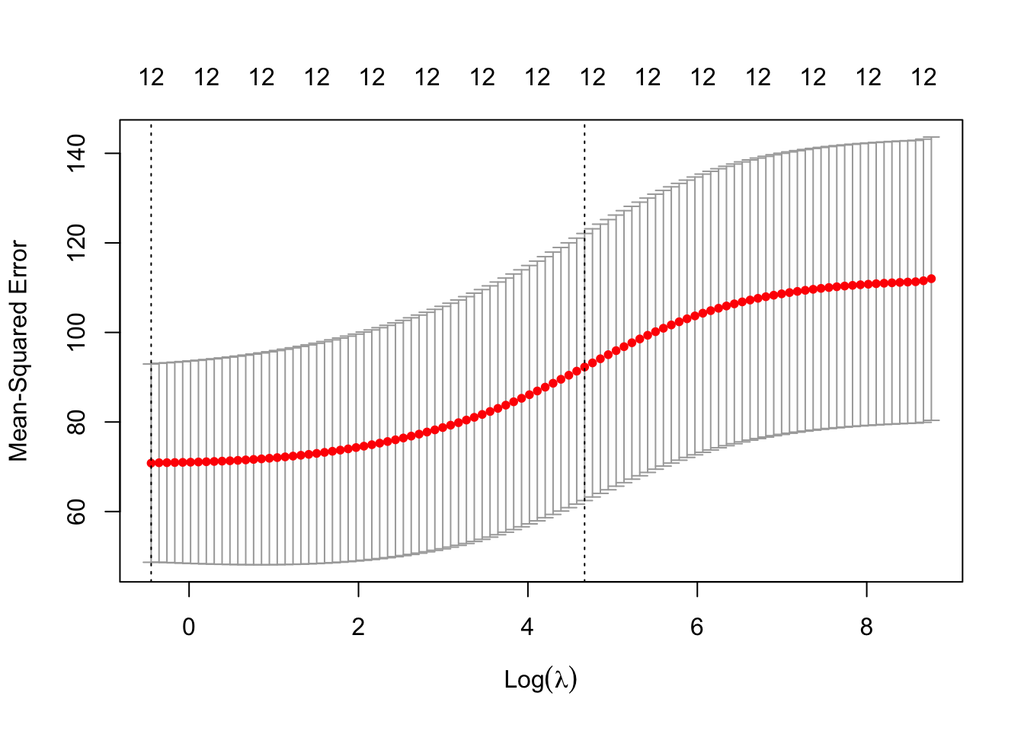

```r
cv.out <- cv.glmnet(x[train, ], y[train], alpha = 0)
plot(cv.out)
```

```r
bestlam <- cv.out$lambda.min
bestlam
```

```
## [1] 0.6390874
```

```r
ridge.pred <- predict(ridge.mod, s = bestlam, newx = x[test, ])
mean((ridge.pred - y.test)^2)
```

```
## [1] 14.47811
```

```r
options(scipen=999)
out <- glmnet(x, y, alpha = 0)
predict(out, type = "coefficients", s = bestlam)[1:13, ]
```

```
##   (Intercept)            zn         indus          chas           nox
##  4.3364532357  0.0325299452 -0.0759638545 -0.8313331628 -4.3349909600
##            rm           age           dis           rad           tax
##  0.4970924564  0.0004045942 -0.6864535596  0.4269807535  0.0043082105
##       ptratio         lstat          medv
## -0.1477203724  0.1564277633 -0.1517955472
```

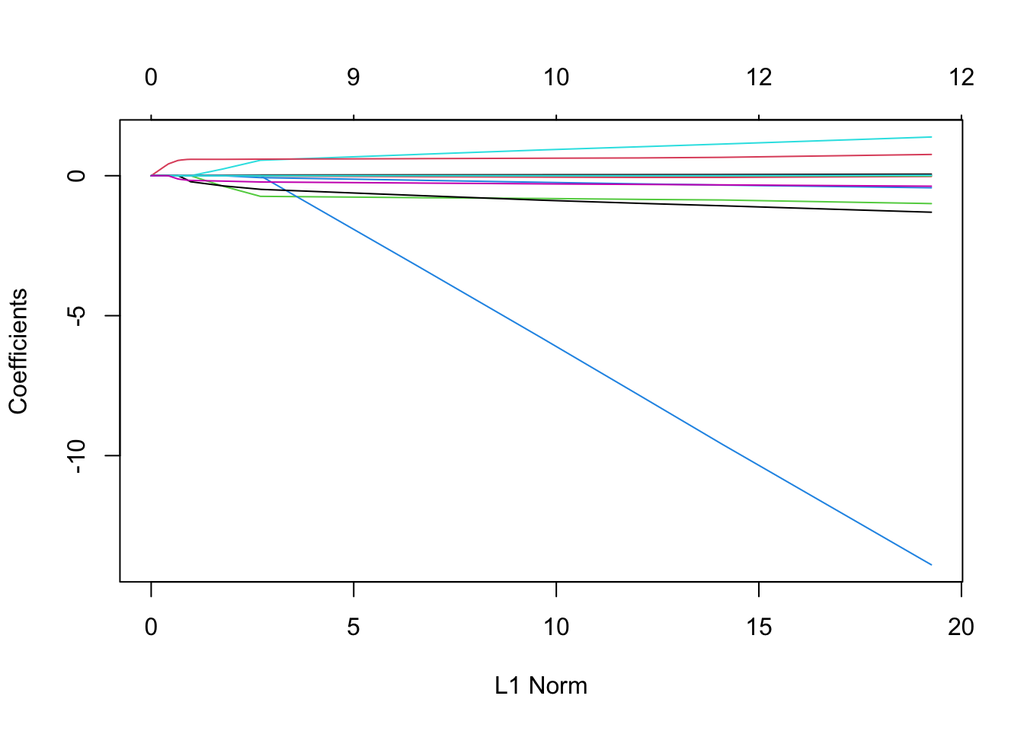

```r
# Lasso

set.seed(506)
train <- sample(1:nrow(x), nrow(x) / 2)
test <- (-train)
y.test <- y[test]

lasso.mod <- glmnet(x[train, ], y[train], alpha = 1, lambda = grid)
plot(lasso.mod)
```

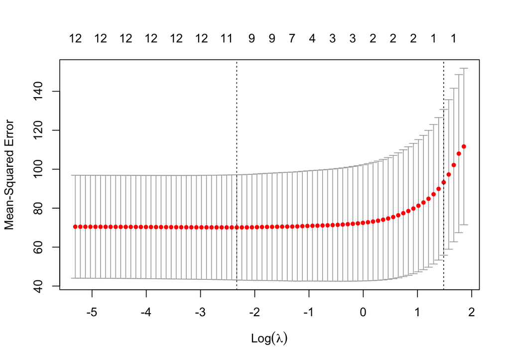

```r
set.seed(506)

cv.out <- cv.glmnet(x[train, ], y[train], alpha = 1)
plot(cv.out)
```

```r
bestlam <- cv.out$lambda.min
lasso.pred <- predict(lasso.mod, s = bestlam,newx = x[test, ])

mean((lasso.pred - y.test)^2)
```

```
## [1] 19.41168
```

```r
out <- glmnet(x, y, alpha = 1, lambda = grid)
lasso.coef <- predict(out, type = "coefficients", s = bestlam)[1:13, ]
lasso.coef
```

```
## (Intercept)          zn       indus        chas         nox          rm
##  6.34099077  0.03284130 -0.04649973 -0.59929734 -3.76851424  0.22687249
##         age         dis         rad         tax     ptratio       lstat
##  0.00000000 -0.62731067  0.52100535  0.00000000 -0.14771428  0.12773698
##        medv
## -0.14918369
```

```r
# Principal Component Regression (PCR)

set.seed(506)

pcr.fit <- pcr(crim ~ ., data = Boston, scale = TRUE, validation = "CV")
summary(pcr.fit)
```

```
## Data:    X dimension: 506 12
##  Y dimension: 506 1
## Fit method: svdpc
## Number of components considered: 12
##
## VALIDATION: RMSEP
## Cross-validated using 10 random segments.
##        (Intercept)  1 comps  2 comps  3 comps  4 comps  5 comps  6 comps
## CV            8.61    7.275    7.270    6.862    6.843    6.798    6.781
## adjCV         8.61    7.272    7.267    6.858    6.840    6.794    6.777
##        7 comps  8 comps  9 comps  10 comps  11 comps  12 comps
## CV       6.654    6.662    6.642     6.643     6.580     6.499
## adjCV    6.645    6.656    6.637     6.637     6.573     6.493
##
## TRAINING: % variance explained
##       1 comps  2 comps  3 comps  4 comps  5 comps  6 comps  7 comps  8 comps
## X       49.93    63.64    72.94    80.21    86.83    90.26    92.79    94.99
## crim    29.39    29.55    37.39    37.85    38.85    39.23    41.73    41.82
##       9 comps  10 comps  11 comps  12 comps
## X       96.78     98.33     99.48    100.00
## crim    42.12     42.43     43.58     44.93
```

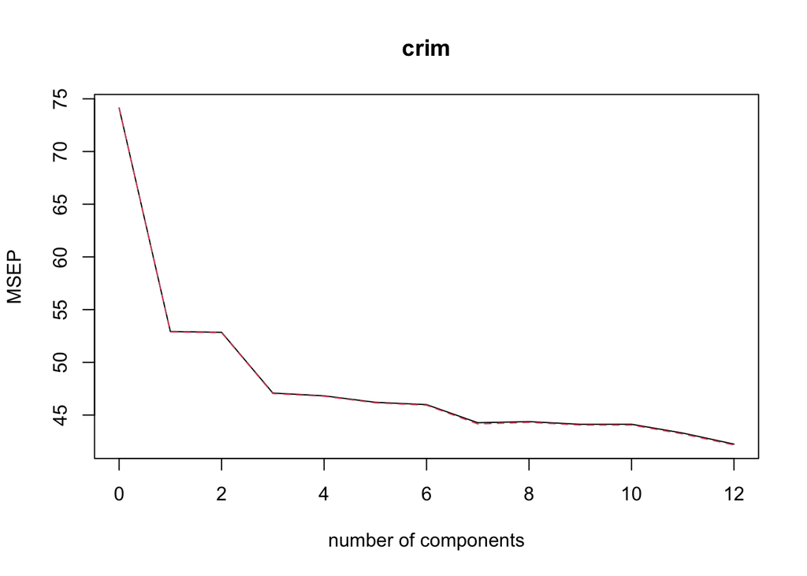

```r
validationplot(pcr.fit, val.type = "MSEP")
```

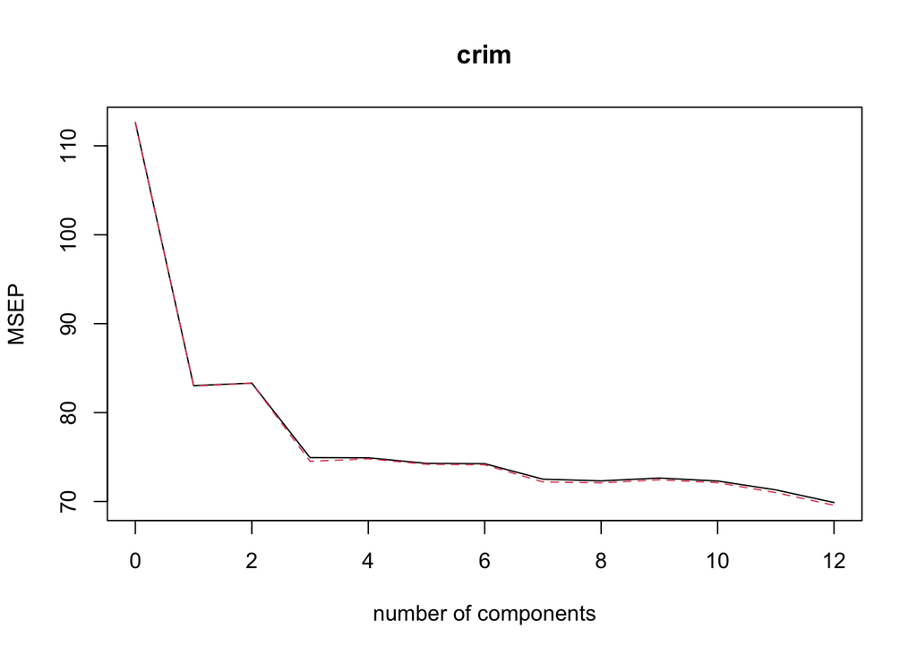

```r
# Smallest cross validation error when M = 12


set.seed(506)
pcr.fit <- pcr(crim ~ ., data = Boston, subset = train, scale = TRUE, validation = "CV")
validationplot(pcr.fit, val.type = "MSEP")
```

```r
pcr.pred <- predict(pcr.fit, x[test, ], ncomp = 8)
mean((pcr.pred - y.test)^2)
```

```
## [1] 19.71289
```

```r
pcr.fit <- pcr(y ~ x, scale = TRUE, ncomp = 8)
summary(pcr.fit)
```

```
## Data:    X dimension: 506 12
##  Y dimension: 506 1
## Fit method: svdpc
## Number of components considered: 8
## TRAINING: % variance explained
##    1 comps  2 comps  3 comps  4 comps  5 comps  6 comps  7 comps  8 comps
## X    49.93    63.64    72.94    80.21    86.83    90.26    92.79    94.99
## y    29.39    29.55    37.39    37.85    38.85    39.23    41.73    41.82
```

```r
# Partial Least Squares (PLS)

set.seed(506)

pls.fit <- plsr(crim ~ ., data = Boston, subset = train, scale = TRUE, validation = "CV")
summary(pls.fit)
```

```
## Data:    X dimension: 253 12
##  Y dimension: 253 1
## Fit method: kernelpls
## Number of components considered: 12
##
## VALIDATION: RMSEP
## Cross-validated using 10 random segments.
##        (Intercept)  1 comps  2 comps  3 comps  4 comps  5 comps  6 comps
## CV           10.61    8.945    8.486    8.396    8.418    8.386    8.389
## adjCV        10.61    8.942    8.478    8.368    8.391    8.367    8.369
##        7 comps  8 comps  9 comps  10 comps  11 comps  12 comps
## CV       8.369    8.363    8.358     8.360     8.360     8.359
## adjCV    8.350    8.344    8.340     8.342     8.341     8.341
##
## TRAINING: % variance explained
##       1 comps  2 comps  3 comps  4 comps  5 comps  6 comps  7 comps  8 comps
## X       52.76    61.36    64.52    70.97    79.98    83.75    88.29    92.28
## crim    29.55    38.07    41.11    41.69    41.94    42.27    42.36    42.44
##       9 comps  10 comps  11 comps  12 comps
## X       94.70     96.30     98.31    100.00
## crim    42.48     42.48     42.48     42.48
```

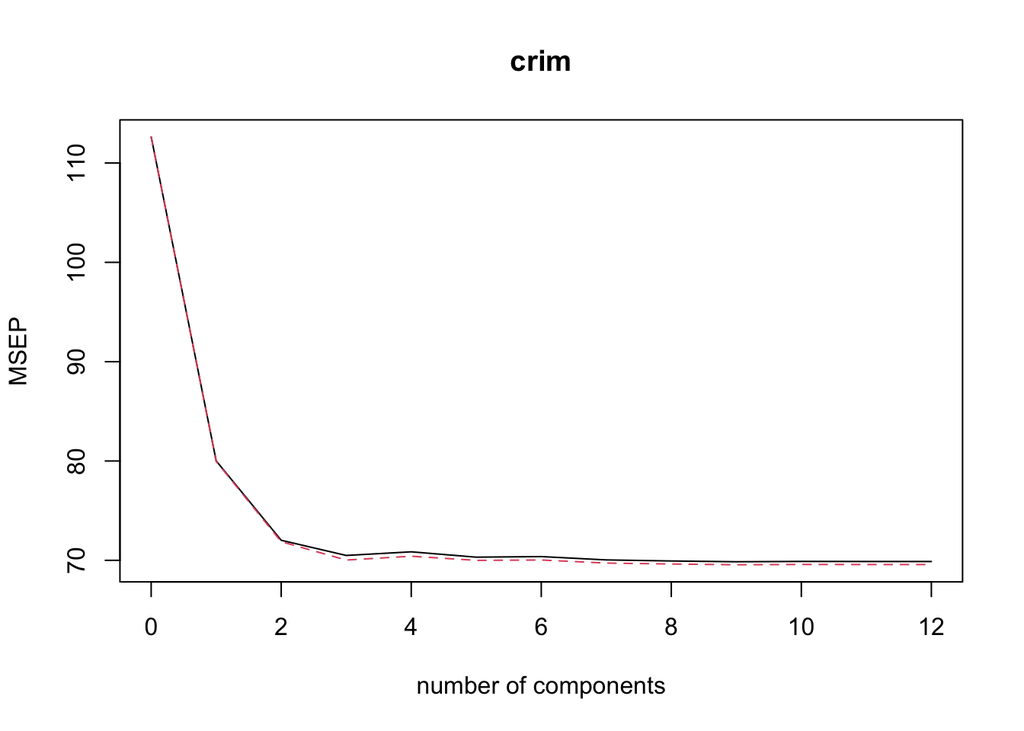

```r
validationplot(pls.fit, val.type = "MSEP")
```

```r
# Use M = 2

pls.pred <- predict(pls.fit, x[test, ], ncomp = 2)
mean((pls.pred - y.test)^2)
```

```
## [1] 20.20811
```

```r
pls.fit <- plsr(crim ~ ., data = Boston, scale = TRUE, ncomp = 2)
summary(pls.fit)
```

```
## Data:    X dimension: 506 12
##  Y dimension: 506 1
## Fit method: kernelpls
## Number of components considered: 2
## TRAINING: % variance explained
##       1 comps  2 comps
## X       49.49    58.85
## crim    33.00    41.20
```

Ridge Regression: Value of λ that results in the smallest cross validation error is 0.6390874 Test MSE is 14.47811

Lasso: MSE is 19.41168. Results in two variables with coefficients of exactly 0 (age and tax)

PCR: MSE is 19.71289.

Partial Least Squares: MSE is 20.20811.

The model with the lowest MSE is Ridge Regression, so I will be using this for the Boston crime model.

### b) Propose a model that seem to perform well on this data set, and justify your answer.

```r
# Lasso Test MSE

x <- model.matrix(crim ~ ., data = Boston)[, -1]
y <- Boston$crim

grid <- 10^seq(10, -2, length = 100)
ridge.mod <- glmnet(x, y, alpha = 0, lambda = grid)

rr_fit <- glmnet(x[train, ], y[train], alpha = 0, lambda = grid)
predict(ridge.mod, s = 0.6390874, type = "coefficients")[1:13, ]
```

```
##   (Intercept)            zn         indus          chas           nox
##  4.3584009308  0.0324123560 -0.0753058514 -0.8296740286 -4.3651551777
##            rm           age           dis           rad           tax
##  0.5009790354  0.0002792911 -0.6862692490  0.4271768985  0.0042992425
##       ptratio         lstat          medv
## -0.1488131099  0.1564788745 -0.1520860808
```

```r
set.seed(506)
train <- sample(1:nrow(x), nrow(x) / 2)
test <- (-train)
y.test <- y[test]

ridge.mod <- glmnet(x[train, ], y[train], alpha = 0, lambda = grid, thresh = 1e-12)
ridge.pred <- predict(ridge.mod, s = 4, newx = x[test, ])
mean((ridge.pred - y.test)^2)
```

```
## [1] 17.07561
```

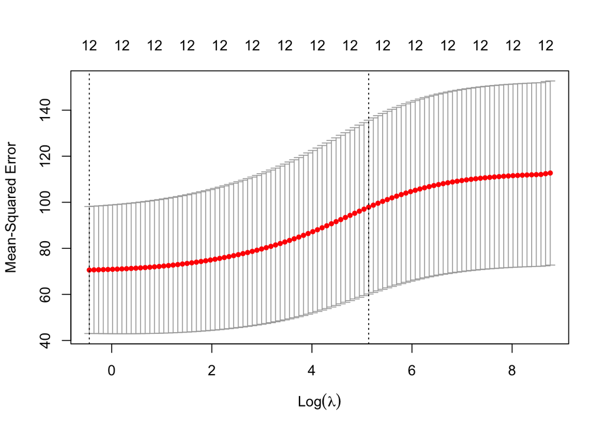

```r
set.seed(506)
cv.out <- cv.glmnet(x[train, ], y[train], alpha = 0)
plot(cv.out)
```

```r
bestlam <- cv.out$lambda.min
bestlam
```

```
## [1] 0.6390874
```

```r
ridge.pred <- predict(ridge.mod, s = bestlam, newx = x[test, ])
mean((ridge.pred - y.test)^2)
```

```
## [1] 18.54927
```

```r
out <- glmnet(x, y, alpha = 0)
predict(out, type = "coefficients", s = bestlam)[1:13, ]
```

```
##   (Intercept)            zn         indus          chas           nox
##  4.3364532357  0.0325299452 -0.0759638545 -0.8313331628 -4.3349909600
##            rm           age           dis           rad           tax
##  0.4970924564  0.0004045942 -0.6864535596  0.4269807535  0.0043082105
##       ptratio         lstat          medv
## -0.1477203724  0.1564277633 -0.1517955472
```

#### Does your chosen model involve all of the features in the data set? Why or why not?

Because this is a ridge regression model, which does not perform variable selection, all the variables are included in the model.

Crime = 0.0325299452zn + -0.0759638545indus, -0.8313331628chas + -4.3349909600nox + 0.4970924564rm + 0.0004045942age + -0.6864535596 dis + 0.4269807535rad + 0.0043082105tax + -0.1477203724ptratio + 0.1564277633lstat + -0.1517955472medv

…